# `lvish` Gallery

This is part of the documentation for uwot.

This page is a gallery of images of the result of running the `lvish` function on some datasets. For all intents and purposes, it should perform very similarly to the [LargeVis](https://arxiv.org/abs/1602.00370) method (see also its [github](https://github.com/lferry007/LargeVis)).

For details on the datasets, and to compare with the output of UMAP and t-SNE, see the [UMAP examples gallery](https://jlmelville.github.io/uwot/umap-examples.html).

## Gaussian Perplexity

By default, `lvish` uses a Gaussian similarity function to determine perplexities, just like t-SNE. These results are given below.

There are two images per dataset. The left-hand image uses a perplexity of 15, which is similar to the sort of settings UMAP uses. The right-hand image is for a perplexity of 50, which is the LargeVis default.

The only other non-default settings was to use `pca = 100`, which reduces the input dimensionality to 100.

```r
iris_lv15 <- lvish(iris, pca = 100, perplexity = 15)
iris_lv50 <- lvish(iris, pca = 100, perplexity = 50)
```

Note that by default `lvish` uses a random initialization and a much larger number of epochs to match the LargeVis defaults. This makes the optimization take a lot longer than UMAP. LargeVis uses multiple threads during the optimization phase, but `lvish` does not, to ensure reproducibility of results with a fixed random seed. To get multi-threaded performance like LargeVis, add the option, `n_sgd_threads = "auto"`, e.g.:

```r
iris_lv15 <- lvish(iris, pca = 100, perplexity = 15, n_sgd_threads = "auto")
```

I would also suggest that you fix the number of epochs to a smaller value initially and see if that provides an adequate visualization.

```r
iris_lv15 <- lvish(iris, pca = 100, perplexity = 15, n_sgd_threads = "auto", n_epochs = 500)
```

### iris

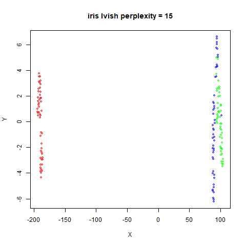

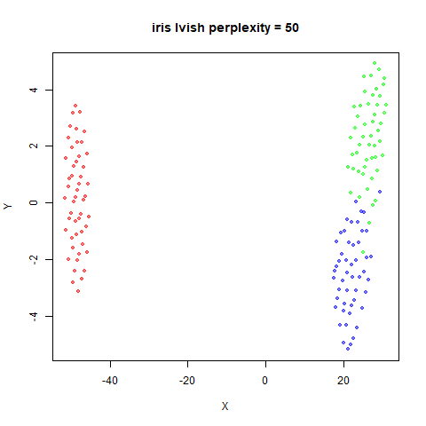

### s1k

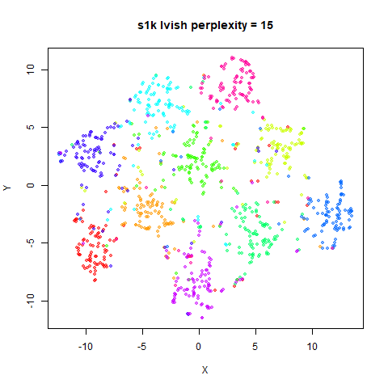

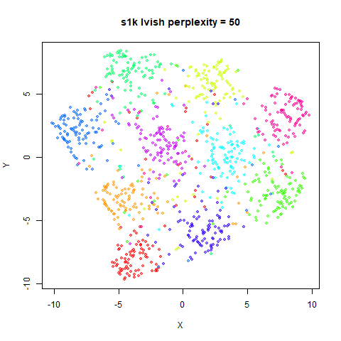

### oli

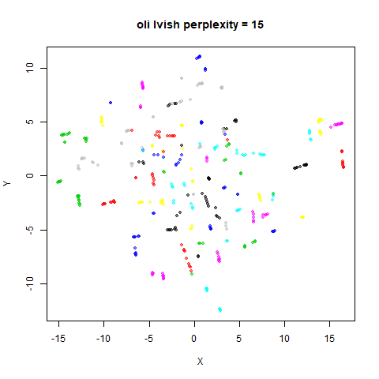

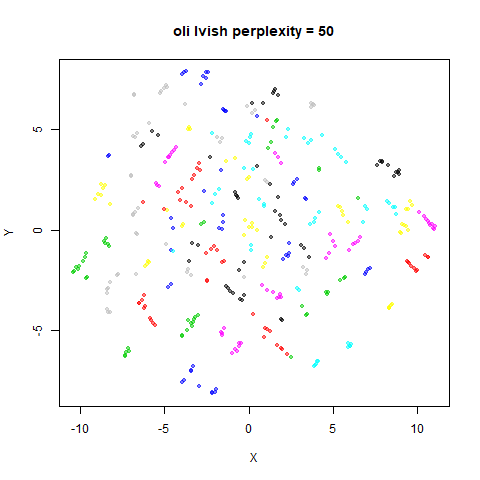

### frey

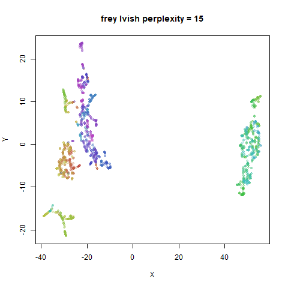

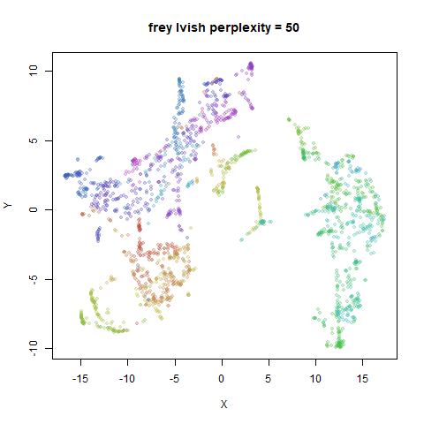

### coil20

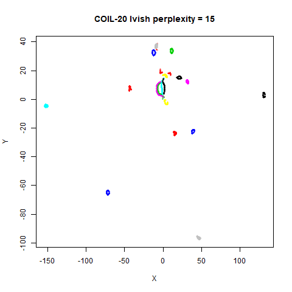

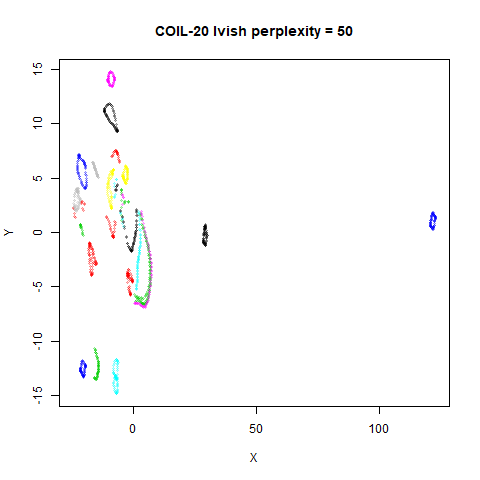

### coil100

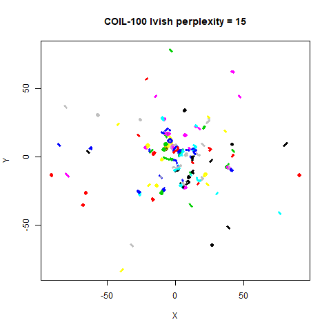

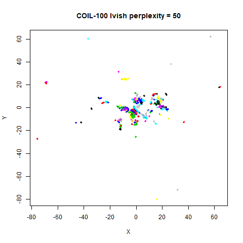

### mnist

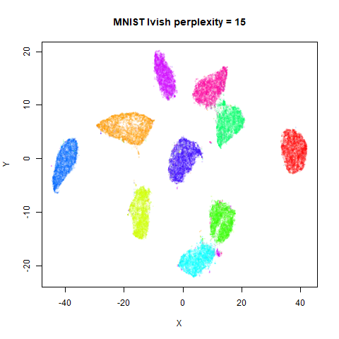

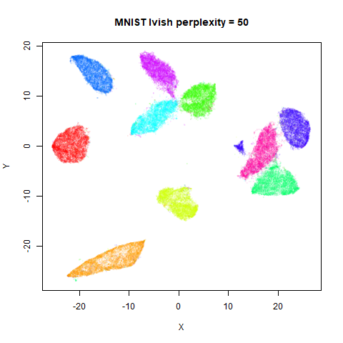

### fashion

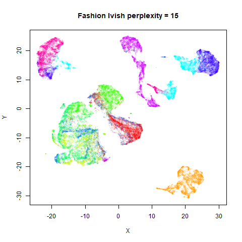

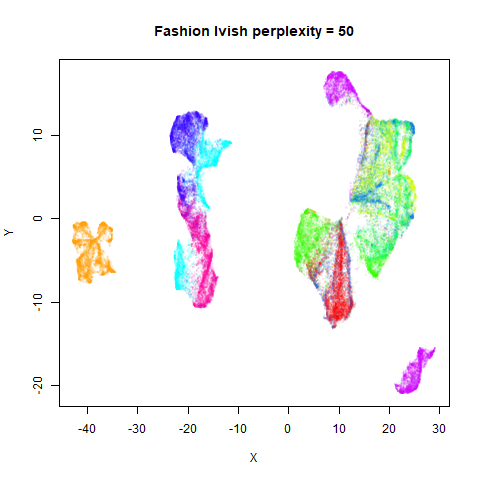

### kuzushiji

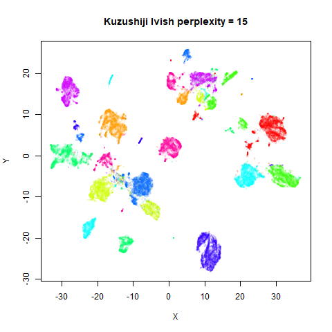

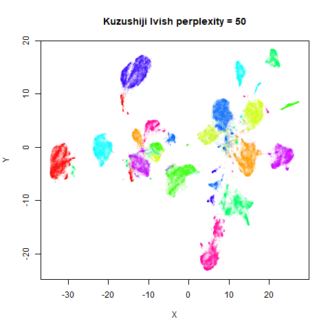

### norb

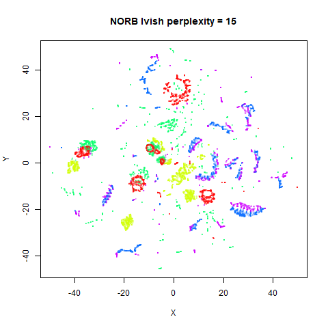

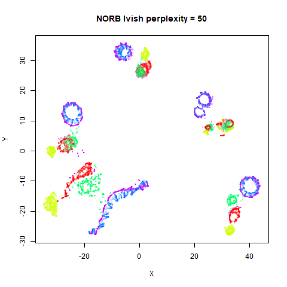

### tasic2018

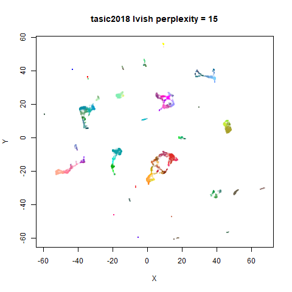

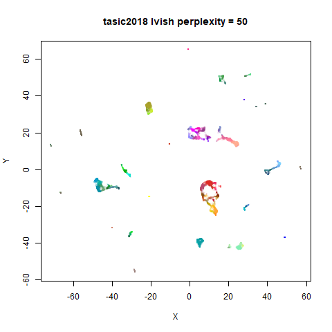

### macosko2015

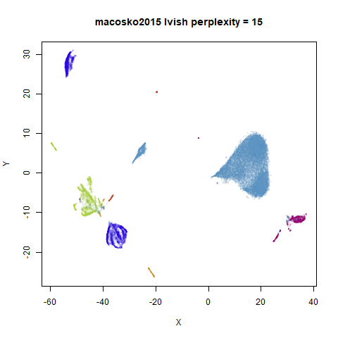

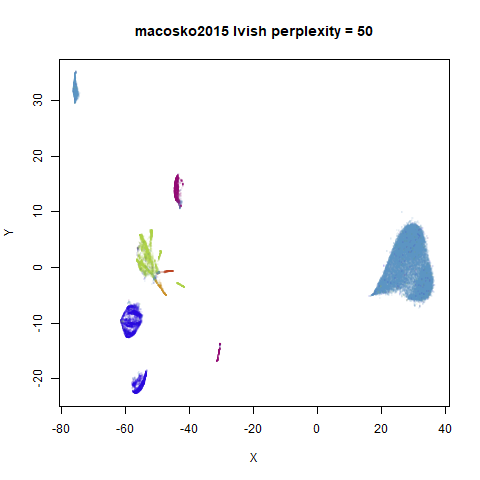

Default initialization in `lvish`, as with LargeVis and t-SNE, is from a random distribution. As with t-SNE, you can see one issue with that is that sometimes clusters get split up by another cluster and are unable to re-merge. MNIST is the easiest example image to see this in.

On the other hand, it’s hard to see what’s going on with the `coil20` and especially the `coil100` results. If you *could* see what was going on from the static images above, it would be apparent that, in contrast to the `norb` results, the `perplexity = 50` results are too high here, and the loop structure of the clusters gets broken up.

The `coil100` and `coil20` results show an issue with using LargeVis (and UMAP) that isn’t normally a problem with t-SNE: the extra repulsion in their cost function can often spread the data quite far apart compared to the cluster sizes. t-SNE has the opposite problem of the clusters expanding into a large circular form which makes discerning clusters harder as the datasets get larger, but in a single static plot, I find the t-SNE results to be easier to examine. For UMAP and `lvish`, you may have to resort to more interactive means of examining the data, such as using the `embed_plotly` function in vizier.

An alternative for `lvish` is to modify the `repulsion_strength` parameter (referred to as `gamma` in LargeVis). The default value, `7` is taken from the LargeVis paper but seems to have been chosen empiricially. Here are results for `coil20` and `perplexity = 50` with the repulsion reduced to `repulsion_strength = 0.7` in the left image, and `repulsion_strength = 0.07` on the right:

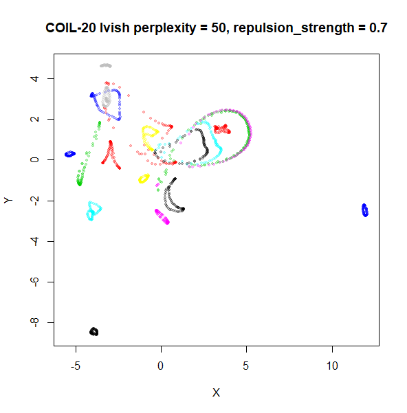

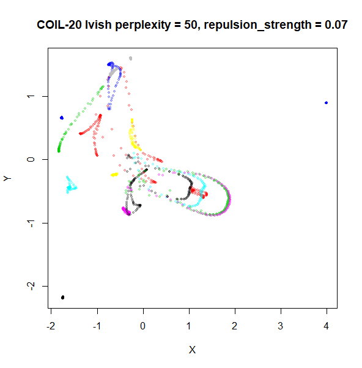

This helps a bit, but there are limits: the blue cluster on the right remains an outlier, and reducing the `repulsion_strength` too far causes some of the loops to shrink, as can be seen with the outlying blue and black clusters for the right-hand plot.

## KNN Perplexity

As an alternative to using the Gaussian perplexities, you could use the k-nearest neighbor graph directly, which involves setting the similarity of $i$ with $j$ to 1 if $i$ is in the k-nearest neighbors of $j$, and 0 otherwise. The usual t-SNE procedure of symmetrizing (but not the normalization step) is then carried out. There are some t-SNE implementations which use kNN-derived perplexities, e.g. [the majorization-minimization approach of Yang and co-workers](http://proceedings.mlr.press/v38/yang15a.html).

The advantage of using the kNN kernel is that you get a sparser set of edges, which due to `lvish` using the same formula for determining the number of iterations required, results in a shorter run time.

For the results below the kNN perplexities were used by setting `kernel = "knn"`

```r
iris_lv15k <- lvish(iris, pca = 100, perplexity = 15, kernel = "knn")
iris_lv50k <- lvish(iris, pca = 100, perplexity = 50, kernel = "knn")
```

For comparison, the top row of images use the same settings as in the previous section with Gaussian perplexities, and the bottom row show the results for using the kNN kernel. The run time for each embedding is given in the image. I used version 0.1.3 of `uwot` from CRAN.

### iris

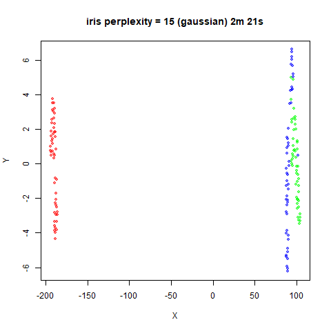

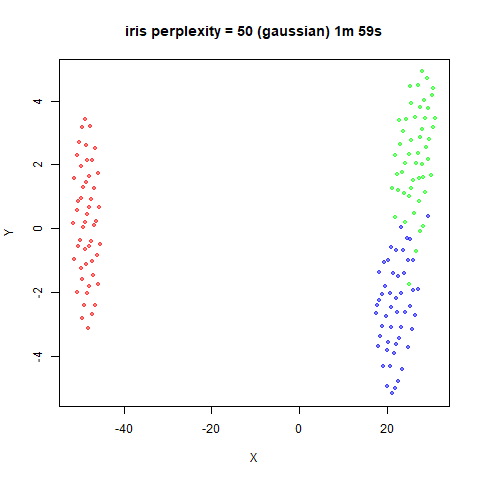

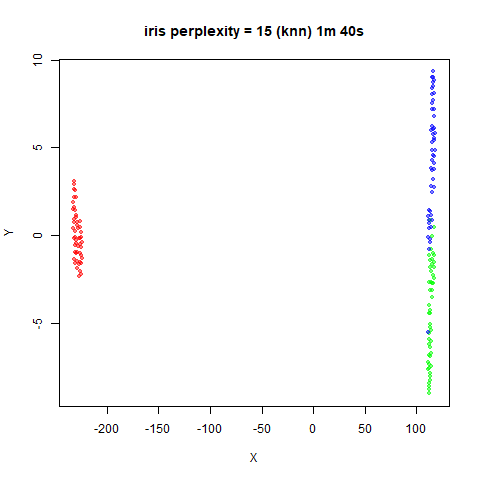

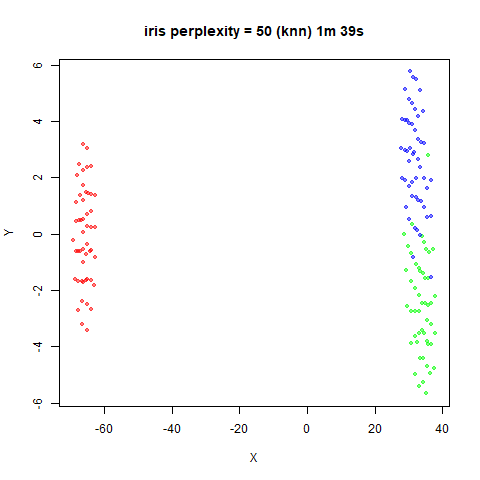